# Data_analysis

Separate panels

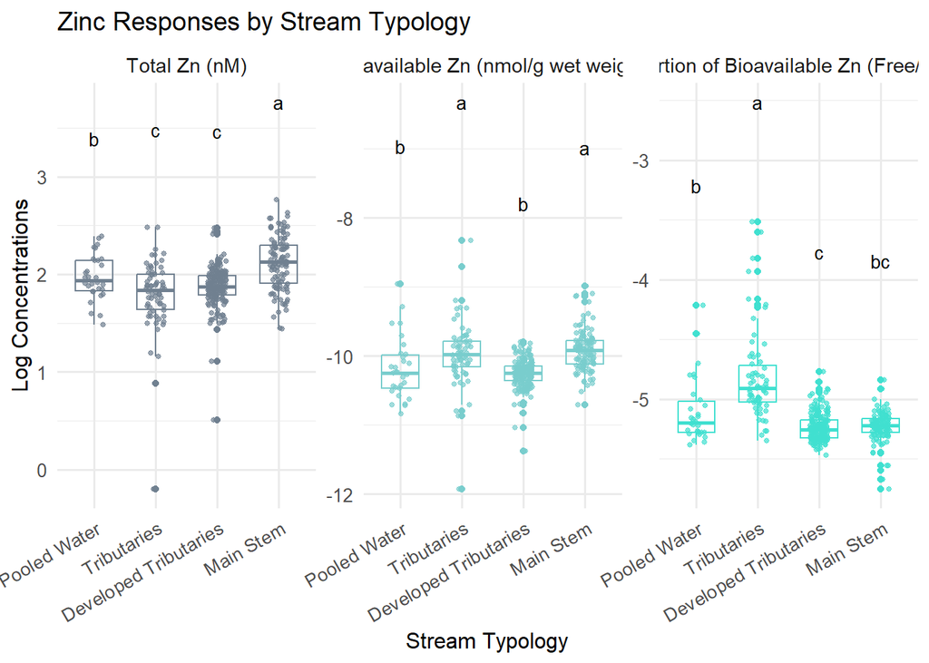

```r
library(dplyr)
library(tidyr)
library(ggplot2)

#-------------------------------------------------
# 1. Colors by response variable (your mapping)
#-------------------------------------------------
response_colors <- c(
  "Total Zn (nM)"                              = "slategray",
  "Bioavailable Zn (nmol/g wet weight)"        = "darkslategray3",
  "Proportion of Bioavailable Zn (Free/Total)" = "turquoise",
  "Total Cu (nM)"                              = "chocolate4",
  "Bioavailable Cu (nmol/g wet weight)"        = "peru",
  "Proportion of Bioavailable Cu (Free/Total)" = "chocolate1"
)

#-------------------------------------------------
# 2. Map variable names -> response labels
#-------------------------------------------------
response_lookup <- c(
  "log_Zn_nM"         = "Total Zn (nM)",
  "log_TBL_Zn_nmol_g" = "Bioavailable Zn (nmol/g wet weight)",
  "log_rel_prop_Zn"   = "Proportion of Bioavailable Zn (Free/Total)",
  "log_Cu_nM"         = "Total Cu (nM)",
  "log_TBL_Cu_nmol_g" = "Bioavailable Cu (nmol/g wet weight)",
  "log_rel_prop_Cu"   = "Proportion of Bioavailable Cu (Free/Total)"
)

vars_trace <- names(response_lookup)

#-------------------------------------------------
# 3. Custom multipliers for letter heights per plot
#    (names must match Response levels)
#-------------------------------------------------
letter_nudge <- c(
  "Total Zn (nM)"                              = 1,
  "Bioavailable Zn (nmol/g wet weight)"        = 2,
  "Proportion of Bioavailable Zn (Free/Total)" = 1,
  "Total Cu (nM)"                              = 1,
  "Bioavailable Cu (nmol/g wet weight)"        = 2,
  "Proportion of Bioavailable Cu (Free/Total)" = 1
)

#-------------------------------------------------
# 4. Long data for plotting (use Typology)
#-------------------------------------------------
dat_long_trace <- dat %>%
  dplyr::select(Typology, all_of(vars_trace)) %>%
  pivot_longer(
    cols      = -Typology,
    names_to  = "Variable",
    values_to = "Value"
  ) %>%
  filter(!is.na(Value)) %>%
  mutate(
    Response = response_lookup[Variable],
    Response = factor(Response, levels = names(response_colors))
  )

#-------------------------------------------------
# 5. Letters (from letters_df) for all 6 variables
#-------------------------------------------------

# 5a. Max y per Variable x Typology
y_pos_df <- dat_long_trace %>%
  group_by(Variable, Typology) %>%
  summarise(y_max = max(Value, na.rm = TRUE), .groups = "drop")

# 5b. Attach Response + y positions + nudges to letters_df
#     letters_df must have: Variable, Typology, Letters
letters_long_trace <- letters_df %>%
  filter(Variable %in% vars_trace) %>%
  mutate(
    Response = response_lookup[Variable],
    Response = factor(Response, levels = names(response_colors))
  ) %>%
  left_join(
    y_pos_df,
    by = c("Variable", "Typology")
  ) %>%
  mutate(
    y_pos = y_max + letter_nudge[as.character(Response)]
  )

#=================================================
# 6. SPLIT INTO ZINC vs COPPER PANELS
#=================================================

zn_responses <- c(
  "Total Zn (nM)",
  "Bioavailable Zn (nmol/g wet weight)",
  "Proportion of Bioavailable Zn (Free/Total)"
)

cu_responses <- c(
  "Total Cu (nM)",
  "Bioavailable Cu (nmol/g wet weight)",
  "Proportion of Bioavailable Cu (Free/Total)"
)

# ---- Zinc-only data ----
dat_long_zn <- dat_long_trace %>%
  filter(Response %in% zn_responses)

letters_long_zn <- letters_long_trace %>%
  filter(Response %in% zn_responses)

bioavail_panel_zn <- ggplot(
  dat_long_zn,
  aes(x = Typology, y = Value, color = Response)
) +
  geom_boxplot(fill = NA, width = 0.6) +
  geom_jitter(width = 0.15, size = 1, alpha = 0.7) +
  geom_text(
    data = letters_long_zn,
    aes(x = Typology, y = y_pos, label = Letters),
    inherit.aes = FALSE,
    size = 3.5
  ) +
  scale_color_manual(values = response_colors) +
  facet_wrap(
    ~ Response,
    scales = "free_y",
    ncol   = 3
  ) +
  labs(
    title = "Zinc Responses by Stream Typology",
    x     = "Stream Typology",
    y     = "Log Concentrations"
  ) +
  theme_minimal(base_size = 12) +
  theme(
    legend.position = "none",
    axis.text.x  = element_text(size = 10, angle = 30, hjust = 1),
    axis.text.y  = element_text(size = 10),
    strip.text   = element_text(size = 11),
    plot.title   = element_text(size = 14)
  )

# ---- Copper-only data ----
dat_long_cu <- dat_long_trace %>%
  filter(Response %in% cu_responses)

letters_long_cu <- letters_long_trace %>%
  filter(Response %in% cu_responses)

bioavail_panel_cu <- ggplot(
  dat_long_cu,
  aes(x = Typology, y = Value, color = Response)
) +
  geom_boxplot(fill = NA, width = 0.6) +
  geom_jitter(width = 0.15, size = 1, alpha = 0.7) +
  geom_text(
    data = letters_long_cu,
    aes(x = Typology, y = y_pos, label = Letters),
    inherit.aes = FALSE,
    size = 3.5
  ) +
  scale_color_manual(values = response_colors) +
  facet_wrap(
    ~ Response,
    scales = "free_y",
    ncol   = 3
  ) +
  labs(
    title = "Copper Responses by Stream Typology",
    x     = "Stream Typology",
    y     = "Log Concentrations"
  ) +
  theme_minimal(base_size = 12) +
  theme(
    legend.position = "none",
    axis.text.x  = element_text(size = 10, angle = 30, hjust = 1),
    axis.text.y  = element_text(size = 10),
    strip.text   = element_text(size = 11),
    plot.title   = element_text(size = 14)
  )

# View each separately:
bioavail_panel_zn
```

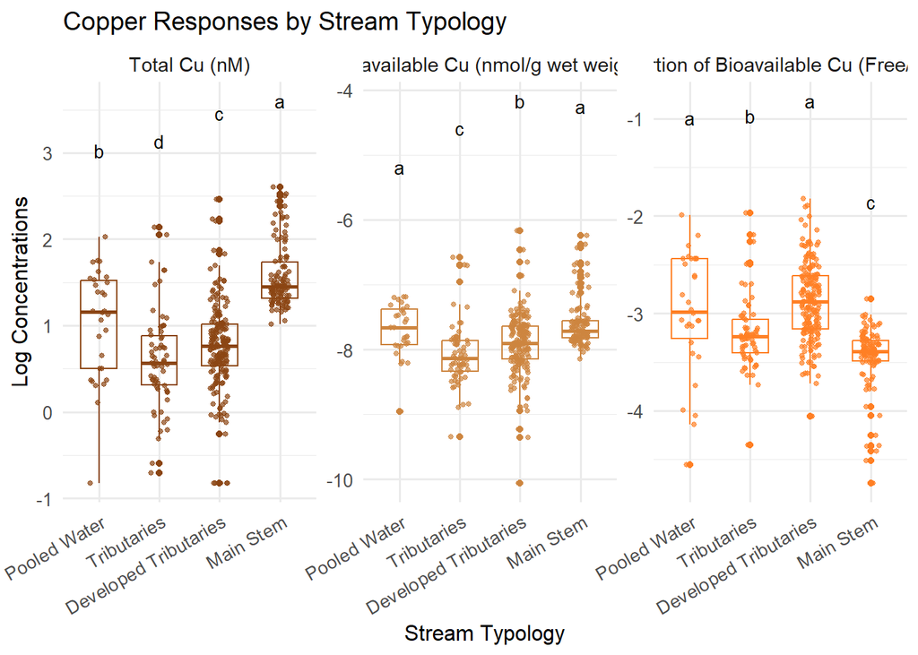

```r
bioavail_panel_cu
```

Save plots

```r
ggsave(
  filename = file.path("Plots by Typology", "Zinc_panel_long.png"),
  plot     = bioavail_panel_zn,
  width    = 10,
  height   = 4,
  dpi      = 300
)

ggsave(
  filename = file.path("Plots by Typology", "Copper_panel_long.png"),
  plot     = bioavail_panel_cu,
  width    = 10,
  height   = 4,
  dpi      = 300
)
```

### c. Factors Affecting Zinc Bioavailability

#### i. Carbonates

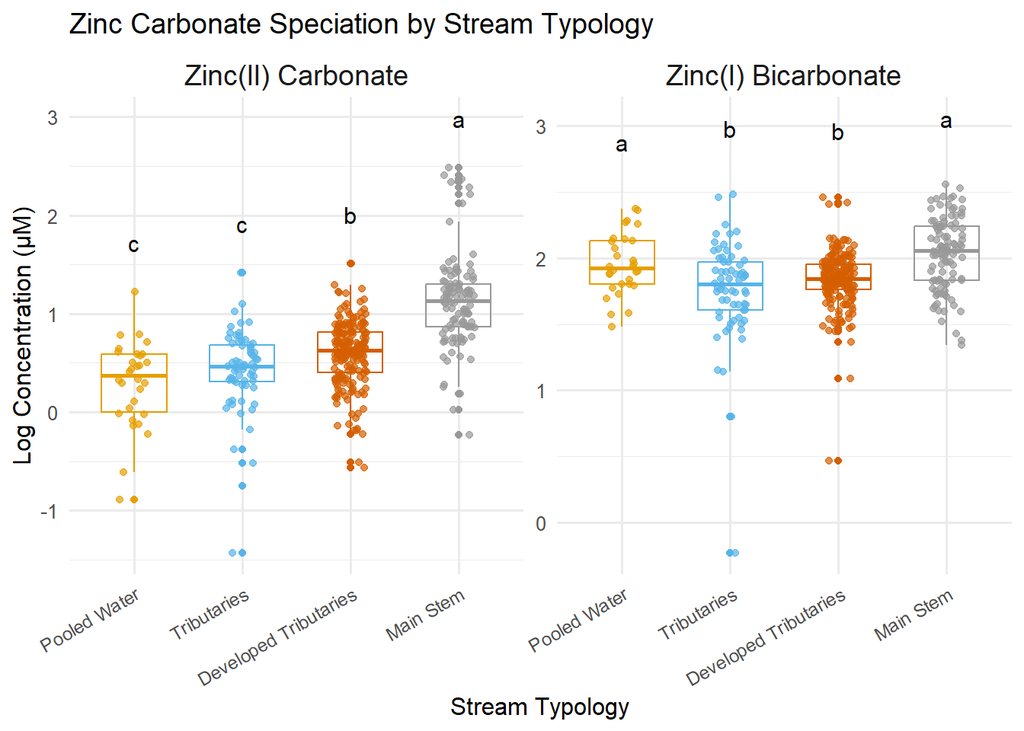

```r
library(dplyr)
library(tidyr)
library(ggplot2)

# ------------------------------------------------
# 0. Variable titles and (optional) y-axis labels
# ------------------------------------------------
title_lookup <- c(
  "log_ZnCO3_nM"  = "Zinc(II) Carbonate",
  "log_ZnHCO3_nM" = "Zinc(I) Bicarbonate"
)

# Custom y-axis labels (optional)
y_label_lookup <- c(
  "log_ZnCO3_nM"  = "log ZnCO3 (nM)",
  "log_ZnHCO3_nM" = "log ZnHCO3 (nM)"
)

vars_zn_spec <- names(title_lookup)

# ------------------------------------------------
# 1. Make sure output folders exist
# ------------------------------------------------
output_dir <- "Plots by Typology"
if (!dir.exists(output_dir)) dir.create(output_dir)

zn_dir <- file.path(output_dir, "Zn Speciation")
if (!dir.exists(zn_dir)) dir.create(zn_dir)

# ------------------------------------------------
# 2. Long-format data for these variables (use Typology)
# ------------------------------------------------
dat_long <- dat %>%
  dplyr::select(Typology, all_of(vars_zn_spec)) %>%
  pivot_longer(
    cols      = -Typology,
    names_to  = "Variable",
    values_to = "Value"
  ) %>%
  filter(!is.na(Value))

# ------------------------------------------------
# 3. Letters for these variables only (from letters_df)
# ------------------------------------------------

# 3a. Max y per Variable x Typology
y_pos_df <- dat_long %>%
  group_by(Variable, Typology) %>%
  summarise(y_max = max(Value, na.rm = TRUE), .groups = "drop")

# 3b. Join letters with y positions
#     letters_df must have: Variable, Typology, Letters
letters_long <- letters_df %>%
  filter(Variable %in% vars_zn_spec) %>%
  left_join(
    y_pos_df,
    by = c("Variable", "Typology")
  ) %>%
  mutate(
    y_pos = y_max + 0.5   # Letters above boxplots
  )

# ------------------------------------------------
# 4. Facet labels using title_lookup
# ------------------------------------------------
facet_labels <- as_labeller(title_lookup)

# ------------------------------------------------
# 5. Build faceted Zn speciation panel
# ------------------------------------------------
zn_speciation_panel <- ggplot(dat_long, aes(
    x     = Typology,
    y     = Value,
    color = Typology
  )) +
  geom_boxplot(fill = NA, width = 0.6) +
  geom_jitter(
    width = 0.15,
    size  = 1.5,
    alpha = 0.7
  ) +
  geom_text(
    data = letters_long,
    aes(x = Typology, y = y_pos, label = Letters),
    inherit.aes = FALSE,
    size = 4
  ) +
  # use your full Typology palette
  scale_color_manual(values = typology_colors) +
  facet_wrap(
    ~ Variable,
    scales   = "free_y",
    ncol     = 3,
    labeller = facet_labels
  ) +
  labs(
    title = "Zinc Carbonate Speciation by Stream Typology",
    x     = "Stream Typology",
    y     = "Log Concentration (µM)"
  ) +
  theme_minimal(base_size = 12) +
  theme(
    legend.position = "none",
    axis.text.x  = element_text(size = 9, angle = 30, hjust = 1),
    strip.text   = element_text(size = 14),
    plot.title   = element_text(size = 14)
  )

# 6. Show in RStudio
zn_speciation_panel
```

Save plot into Zn Speciation subfolder of Plots by Typology

```r
ggsave(
  filename = file.path(zn_dir, "Zn_speciation_carbonates_panel.png"),
  plot     = zn_speciation_panel,
  width    = 8,
  height   = 4,
  dpi      = 300
)
```

#### ii. Calcium

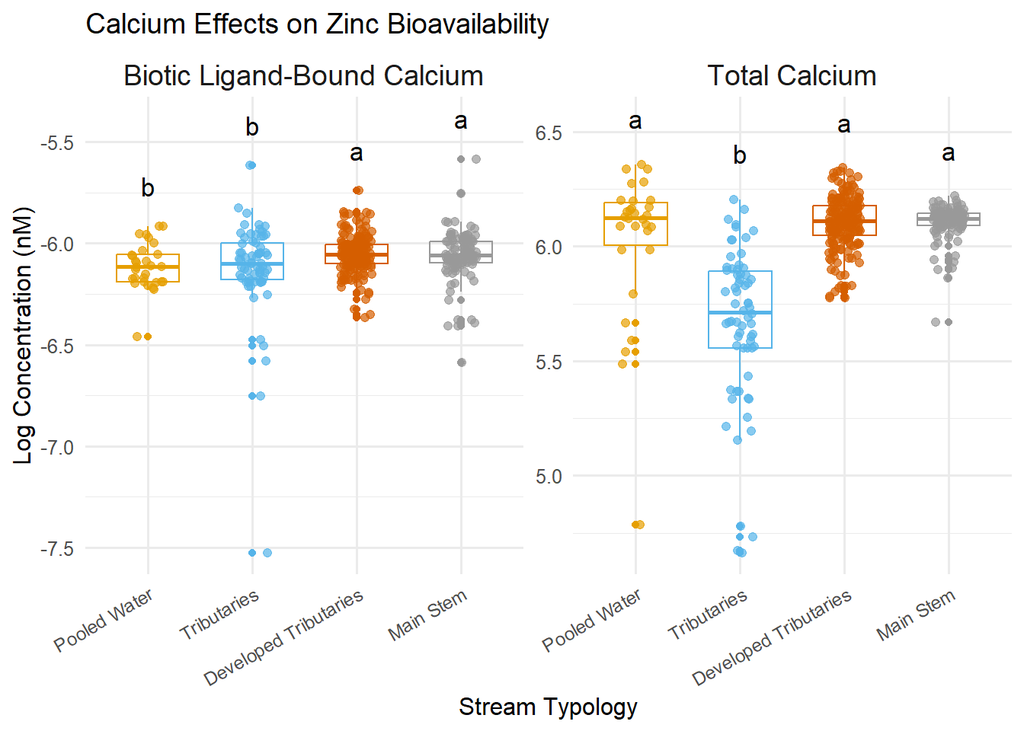

```r
library(dplyr)
library(tidyr)
library(ggplot2)

# ---------------------------------------------
# 1. Titles and (optional) y-axis labels
# ---------------------------------------------
zn_title_lookup <- c(
  "log_Ca_nM"           = "Total Calcium",
  "log_BL_Ca_nmol_g_Zn" = "Biotic Ligand-Bound Calcium"
)

# Optional: custom y-axis labels if you want later
zn_y_label_lookup <- c(
  "log_Ca_nM"           = "log Ca (nM)",
  "log_BL_Ca_nmol_g_Zn" = "log BL-Ca (nmol/g wet weight)"
)

vars_zn_spec <- names(zn_title_lookup)

# ---------------------------------------------
# 2. Output folder: Plots by Typology/Zn Speciation
# ---------------------------------------------
output_dir <- "Plots by Typology"
if (!dir.exists(output_dir)) dir.create(output_dir)

zn_dir <- file.path(output_dir, "Zn Speciation")
if (!dir.exists(zn_dir)) dir.create(zn_dir)

# ---------------------------------------------
# 3. Long-format data for Zn speciation variables (use Typology)
# ---------------------------------------------
dat_long_zn <- dat %>%
  dplyr::select(Typology, all_of(vars_zn_spec)) %>%
  pivot_longer(
    cols      = -Typology,
    names_to  = "Variable",
    values_to = "Value"
  ) %>%
  filter(!is.na(Value))

# ---------------------------------------------
# 4. Custom multipliers for letter height per variable
# ---------------------------------------------
letter_nudge_zn <- c(
  "log_Ca_nM"           = 0.2,
  "log_BL_Ca_nmol_g_Zn" = 0.2
)

# ---------------------------------------------
# 5. Letters for Zn speciation variables (from letters_df)
# ---------------------------------------------

# 5a. Max y per Variable x Typology
y_pos_df_zn <- dat_long_zn %>%
  group_by(Variable, Typology) %>%
  summarise(y_max = max(Value, na.rm = TRUE), .groups = "drop")

# 5b. Join letters with y positions
#     letters_df must have: Variable, Typology, Letters
letters_long_zn <- letters_df %>%
  filter(Variable %in% vars_zn_spec) %>%
  left_join(
    y_pos_df_zn,
    by = c("Variable", "Typology")
  ) %>%
  mutate(
    # add a small offset instead of multiplying
    y_pos = y_max + letter_nudge_zn[Variable]
  )

# ---------------------------------------------
# 6. Build faceted Zn speciation panel
# ---------------------------------------------
facet_labels_zn <- as_labeller(zn_title_lookup)

ca_on_zn_panel <- ggplot(dat_long_zn, aes(
    x     = Typology,
    y     = Value,
    color = Typology
  )) +
  # Boxplots
  geom_boxplot(fill = NA, width = 0.6) +
  # Jittered points
  geom_jitter(
    width = 0.15,
    size  = 1.8,
    alpha = 0.7
  ) +
  # Letters from Kruskal groups
  geom_text(
    data = letters_long_zn,
    aes(x = Typology, y = y_pos, label = Letters),
    inherit.aes = FALSE,
    size = 4.5
  ) +
  # Typology colors (use your Typology palette)
  scale_color_manual(values = typology_colors) +
  # One facet per Zn variable
  facet_wrap(
    ~ Variable,
    scales   = "free_y",
    ncol     = 2,
    labeller = facet_labels_zn
  ) +
  labs(
    title = "Calcium Effects on Zinc Bioavailability",
    x     = "Stream Typology",
    y     = "Log Concentration (nM)"
  ) +
  theme_minimal(base_size = 12) +
  theme(
    legend.position = "none",
    axis.text.x  = element_text(size = 9, angle = 30, hjust = 1),
    strip.text   = element_text(size = 14),
    plot.title   = element_text(size = 14)
  )

# Show in RStudio
ca_on_zn_panel
```

```r
ggsave(
  filename = file.path(zn_dir, "Ca_on_Zn_bioavailability_panel.png"),
  plot     = ca_on_zn_panel,
  width    = 8,
  height   = 4,
  dpi      = 300
)
```

#### iii. Sodium

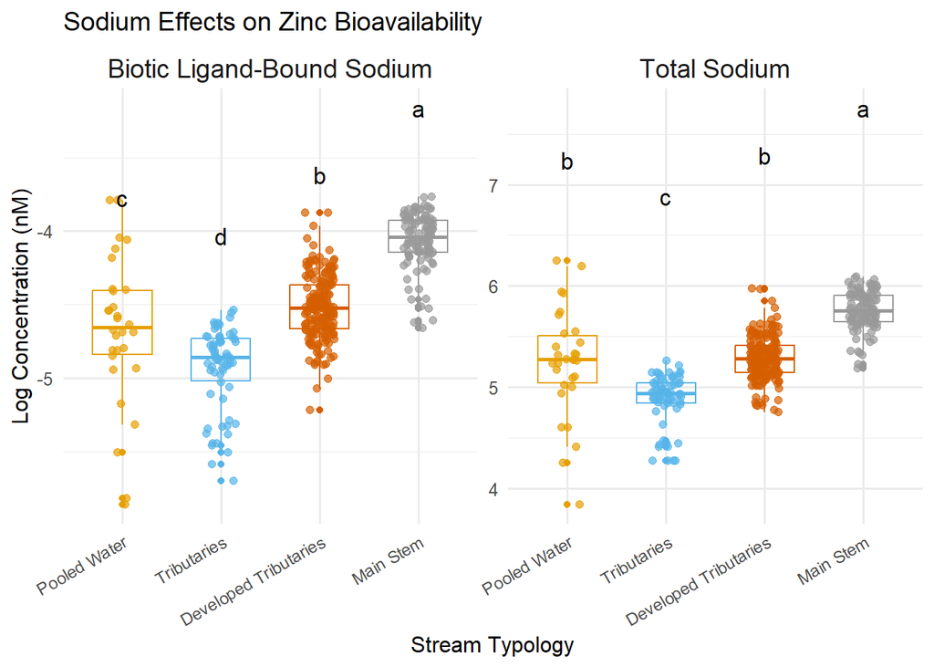

```r
library(dplyr)
library(tidyr)
library(ggplot2)

# ---------------------------------------------
# 1. Titles and (optional) y-axis labels
# ---------------------------------------------
na_title_lookup <- c(
  "log_Na_nM"           = "Total Sodium",
  "log_BL_Na_nmol_g_Zn" = "Biotic Ligand-Bound Sodium"
)

# Optional: y-axis labels
na_y_label_lookup <- c(
  "log_Na_nM"           = "log Na (nM)",
  "log_BL_Na_nmol_g_Zn" = "log BL-Na (nmol/g wet weight)"
)

vars_zn_spec <- names(na_title_lookup)

# ---------------------------------------------
# 2. Output directories
# ---------------------------------------------
output_dir <- "Plots by Typology"
if (!dir.exists(output_dir)) dir.create(output_dir)

zn_dir <- file.path(output_dir, "Zn Speciation")
if (!dir.exists(zn_dir)) dir.create(zn_dir)

# ---------------------------------------------
# 3. Long data for Zn speciation (use Typology)
# ---------------------------------------------
dat_long_zn <- dat %>%
  dplyr::select(Typology, all_of(vars_zn_spec)) %>%
  pivot_longer(
    cols      = -Typology,
    names_to  = "Variable",
    values_to = "Value"
  ) %>%
  filter(!is.na(Value))

# ---------------------------------------------
# 4. Letter nudges per variable
# ---------------------------------------------
letter_nudge_zn <- c(
  "log_Na_nM"           = 2,
  "log_BL_Na_nmol_g_Zn" = 0.9
)

# ---------------------------------------------
# 5. Letters for Zn speciation variables
# ---------------------------------------------

# 5a. Mean y per Variable x Typology
y_pos_df_zn <- dat_long_zn %>%
  group_by(Variable, Typology) %>%
  summarise(y_mean = mean(Value, na.rm = TRUE), .groups = "drop")

# 5b. Join letters with y positions
#     letters_df must have: Variable, Typology, Letters
letters_long_zn <- letters_df %>%
  filter(Variable %in% vars_zn_spec) %>%
  left_join(
    y_pos_df_zn,
    by = c("Variable", "Typology")
  ) %>%
  mutate(
    y_pos = y_mean + letter_nudge_zn[Variable]
  )

# ---------------------------------------------
# 6. Faceted panel for Na effects on Zn
# ---------------------------------------------
facet_labels_zn <- as_labeller(na_title_lookup)

na_on_zn_panel <- ggplot(dat_long_zn, aes(
    x     = Typology,
    y     = Value,
    color = Typology
  )) +
  geom_boxplot(fill = NA, width = 0.6) +
  geom_jitter(width = 0.15, size = 1.8, alpha = 0.7) +
  geom_text(
    data = letters_long_zn,
    aes(x = Typology, y = y_pos, label = Letters),
    inherit.aes = FALSE,
    size = 4.5
  ) +
  scale_color_manual(values = typology_colors) +
  facet_wrap(
    ~ Variable,
    scales   = "free_y",
    ncol     = 2,
    labeller = facet_labels_zn
  ) +
  labs(
    title = "Sodium Effects on Zinc Bioavailability",
    x     = "Stream Typology",
    y     = "Log Concentration (nM)"
  ) +
  theme_minimal(base_size = 12) +
  theme(
    legend.position = "none",
    axis.text.x  = element_text(size = 9, angle = 30, hjust = 1),
    strip.text   = element_text(size = 14),
    plot.title   = element_text(size = 14)
  )

na_on_zn_panel
```

Save

```r
ggsave(
  filename = file.path(zn_dir, "Na_on_Zn_bioavailability_panel.png"),
  plot     = na_on_zn_panel,
  width    = 8,
  height   = 4,
  dpi      = 300
)
```

#### iv. Sulfate

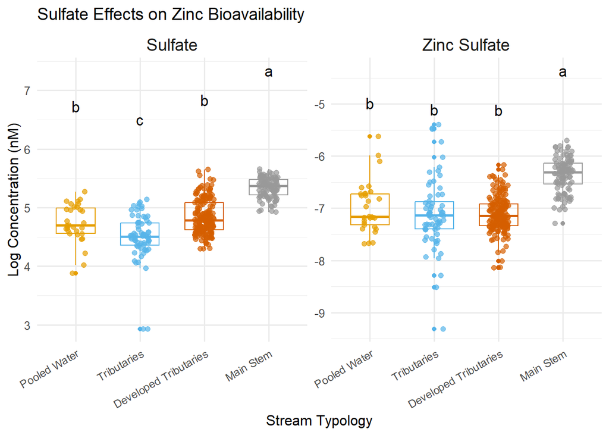

```r
library(dplyr)
library(tidyr)
library(ggplot2)

# ---------------------------------------------
# 1. Titles and (optional) y-axis labels
# ---------------------------------------------
na_title_lookup <- c(
  "log_SO4_nM"   = "Sulfate",
  "log_ZnSO4_nM" = "Zinc Sulfate"
)

# Optional: y-axis labels
na_y_label_lookup <- c(
  "log_SO4_nM"   = "log SO4 (nM)",
  "log_ZnSO4_nM" = "log ZnSO4 (nM)"
)

vars_zn_spec <- names(na_title_lookup)

# ---------------------------------------------
# 2. Output directories
# ---------------------------------------------
output_dir <- "Plots by Typology"
if (!dir.exists(output_dir)) dir.create(output_dir)

zn_dir <- file.path(output_dir, "Zn Speciation")
if (!dir.exists(zn_dir)) dir.create(zn_dir)

# ---------------------------------------------
# 3. Long data for Zn speciation (use Typology)
# ---------------------------------------------
dat_long_zn <- dat %>%
  dplyr::select(Typology, all_of(vars_zn_spec)) %>%
  pivot_longer(
    cols      = -Typology,
    names_to  = "Variable",
    values_to = "Value"
  ) %>%
  filter(!is.na(Value))

# ---------------------------------------------
# 4. Letter nudges per variable
# ---------------------------------------------
letter_nudge_zn <- c(
  "log_SO4_nM"   = 2,
  "log_ZnSO4_nM" = 2
)

# ---------------------------------------------
# 5. Letters for Zn speciation variables
# ---------------------------------------------

# 5a. Mean y per Variable x Typology
y_pos_df_zn <- dat_long_zn %>%
  group_by(Variable, Typology) %>%
  summarise(y_mean = mean(Value, na.rm = TRUE), .groups = "drop")

# 5b. Join letters with y positions
#     letters_df must have: Variable, Typology, Letters
letters_long_zn <- letters_df %>%
  filter(Variable %in% vars_zn_spec) %>%
  left_join(
    y_pos_df_zn,
    by = c("Variable", "Typology")
  ) %>%
  mutate(
    y_pos = y_mean + letter_nudge_zn[Variable]
  )

# ---------------------------------------------
# 6. Faceted panel for sulfate effects on Zn
# ---------------------------------------------
facet_labels_zn <- as_labeller(na_title_lookup)

doc_on_zn_panel <- ggplot(dat_long_zn, aes(
    x     = Typology,
    y     = Value,
    color = Typology
  )) +
  geom_boxplot(fill = NA, width = 0.6) +
  geom_jitter(width = 0.15, size = 1.8, alpha = 0.7) +
  geom_text(
    data = letters_long_zn,
    aes(x = Typology, y = y_pos, label = Letters),
    inherit.aes = FALSE,
    size = 4.5
  ) +
  scale_color_manual(values = typology_colors) +
  facet_wrap(
    ~ Variable,
    scales   = "free_y",
    ncol     = 2,
    labeller = facet_labels_zn
  ) +
  labs(
    title = "Sulfate Effects on Zinc Bioavailability",
    x     = "Stream Typology",
    y     = "Log Concentration (nM)"
  ) +
  theme_minimal(base_size = 12) +
  theme(
    legend.position = "none",
    axis.text.x  = element_text(size = 9, angle = 30, hjust = 1),
    strip.text   = element_text(size = 14),
    plot.title   = element_text(size = 14)
  )

doc_on_zn_panel
```

Save

```r
ggsave(
  filename = file.path(zn_dir, "DOC_on_Zn_bioavailability_panel.png"),
  plot     = doc_on_zn_panel,
  width    = 8,
  height   = 4,
  dpi      = 300
)
```

#### v. Complexing Anions

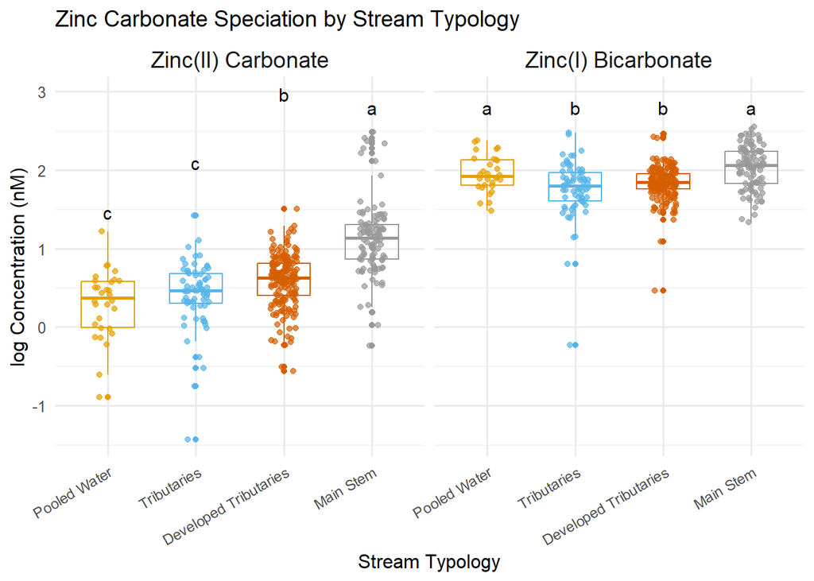

```r
library(dplyr)
library(tidyr)
library(ggplot2)

# ------------------------------------------------
# 0. Variable titles for ZINC
# ------------------------------------------------
zn_title_lookup <- c(
  "log_ZnCO3_nM"  = "Zinc(II) Carbonate",
  "log_ZnHCO3_nM" = "Zinc(I) Bicarbonate"
)

zn_vars <- names(zn_title_lookup)

# ------------------------------------------------
# 1. Output folders
# ------------------------------------------------
output_dir <- "Plots by Typology"
if (!dir.exists(output_dir)) dir.create(output_dir)

zn_dir <- file.path(output_dir, "Zn Speciation")
if (!dir.exists(zn_dir)) dir.create(zn_dir)

# ------------------------------------------------
# 2. Long-format zinc data (use Typology)
# ------------------------------------------------
zn_long <- dat %>%
  dplyr::select(Typology, all_of(zn_vars)) %>%
  pivot_longer(
    cols      = -Typology,
    names_to  = "Variable",
    values_to = "Value"
  ) %>%
  filter(!is.na(Value)) %>%
  mutate(
    Variable = factor(
      Variable,
      levels = zn_vars
    )
  )

# ------------------------------------------------
# 3. Letters for ZINC variables only
#    (includes 5 × y_mean placement with cap)
# ------------------------------------------------

# 3a. Compute group means for letter positioning
y_pos_df <- zn_long %>%
  group_by(Variable, Typology) %>%
  summarise(y_mean = mean(Value, na.rm = TRUE), .groups = "drop")

# 3b. Attach y positions to letters_df (assumes Letters col exists)
letters_zn <- letters_df %>%
  filter(Variable %in% zn_vars) %>%
  mutate(
    Variable = factor(
      Variable,
      levels = zn_vars
    )
  ) %>%
  left_join(
    y_pos_df,
    by = c("Variable", "Typology")
  ) %>%
  mutate(
    y_pos_raw = y_mean * 5,
    y_pos     = ifelse(y_pos_raw > 3, 3 - 0.2, y_pos_raw)
  )

# ------------------------------------------------
# 4. Facet labels for zinc
# ------------------------------------------------
zn_facet_labels <- as_labeller(zn_title_lookup)

# ------------------------------------------------
# 5. Build 2×2 ZINC speciation panel (shared y-axis)
# ------------------------------------------------
zn_speciation_panel <- ggplot(zn_long, aes(
    x     = Typology,
    y     = Value,
    color = Typology
)) +
  geom_boxplot(fill = NA, width = 0.6) +
  geom_jitter(width = 0.15, size = 1.5, alpha = 0.7) +
  geom_text(
    data = letters_zn,
    aes(x = Typology, y = y_pos, label = Letters),
    inherit.aes = FALSE,
    size = 4
  ) +
  scale_color_manual(values = typology_colors) +
  facet_wrap(
    ~ Variable,
    ncol    = 2,          # 2×2 layout
    scales  = "fixed",    # same axes across all panels
    labeller = zn_facet_labels
  ) +
  labs(
    title = "Zinc Carbonate Speciation by Stream Typology",
    x     = "Stream Typology",
    y     = "log Concentration (nM)"
  ) +
  theme_minimal(base_size = 12) +
  theme(
    legend.position = "none",
    axis.text.x  = element_text(size = 9, angle = 30, hjust = 1),
    strip.text   = element_text(size = 14),
    plot.title   = element_text(size = 14)
  )

# 6. Display
zn_speciation_panel
```

Save

```r
ggsave(
filename = file.path(zn_dir, "Zn_complexing_anions_by_typology.png"),
plot     = zn_speciation_panel,
width    = 8,
height   = 4,
dpi      = 300
)
```

### c. Factors Affecting Copper Bioavailability

#### i. Sulfate

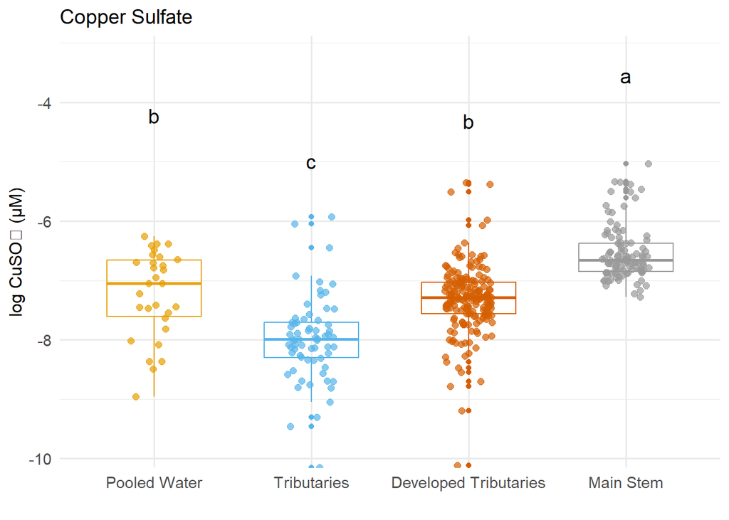

```r
library(dplyr)
library(ggplot2)

#-------------------------------------------------
# 0. Name of the variable you want to plot
#-------------------------------------------------
var_name <- "log_CuSO4_uM"

#-------------------------------------------------
# 1. Titles and y-axis label for this variable
#-------------------------------------------------
title_var   <- "Copper Sulfate"
y_label_var <- "log CuSO₄ (µM)"

#-------------------------------------------------
# 2. Save to an output folder
#-------------------------------------------------
output_dir <- "Plots by Typology"
if (!dir.exists(output_dir)) dir.create(output_dir)

cu_dir <- file.path(output_dir, "Cu Speciation")
if (!dir.exists(cu_dir)) dir.create(cu_dir)

#-------------------------------------------------
# 3. Letters for this variable only (from letters_df)
#-------------------------------------------------
letters_sub <- letters_df %>%
  filter(Variable == var_name)
# letters_df already has columns: Variable, Typology, Letters

#-------------------------------------------------
# 4. y-position for letters: mean + constant offset
#-------------------------------------------------
y_pos_df <- dat %>%
  group_by(Typology) %>%
  summarise(
    y_pos = mean(.data[[var_name]], na.rm = TRUE) + 3,
    .groups = "drop"
  )

# join y_pos into letters_sub by Typology
letters_sub <- letters_sub %>%
  left_join(y_pos_df, by = "Typology")

#-------------------------------------------------
# 5. Build ggplot for log_CuSO4_uM
#-------------------------------------------------
p_cuso4_cu <- ggplot(dat, aes(
    x     = Typology,
    y     = .data[[var_name]],
    color = Typology
  )) +
  geom_boxplot(fill = NA, width = 0.6) +
  geom_jitter(
    width = 0.15,
    size  = 2,
    alpha = 0.7
  ) +
  geom_text(
    data = letters_sub,
    aes(
      x = Typology,
      y = y_pos,
      label = Letters
    ),
    inherit.aes = FALSE,
    size = 5
  ) +
  scale_color_manual(values = typology_colors) +
  labs(
    title = title_var,
    y     = y_label_var,
    x     = ""
  ) +
  scale_y_continuous(expand = expansion(mult = c(0, 0.1))) +
  theme_minimal(base_size = 12) +
  theme(
    legend.position = "none",
    axis.text.x  = element_text(size = 11),
    axis.title.x = element_text(size = 12),
    axis.text.y  = element_text(size = 11),
    axis.title.y = element_text(size = 12),
    plot.title   = element_text(size = 14)
  )

# Show the plot
p_cuso4_cu
```

Save plot into Cu Speciation subfolder of Plots by Typology

```r
ggsave(
  filename = file.path(cu_dir, "CuSO4.png"),
  plot     = p_cuso4_cu,
  width    = 5,
  height   = 4,
  dpi      = 300
)
```

#### ii. Dissolved organic carbon

Just total organic Cu

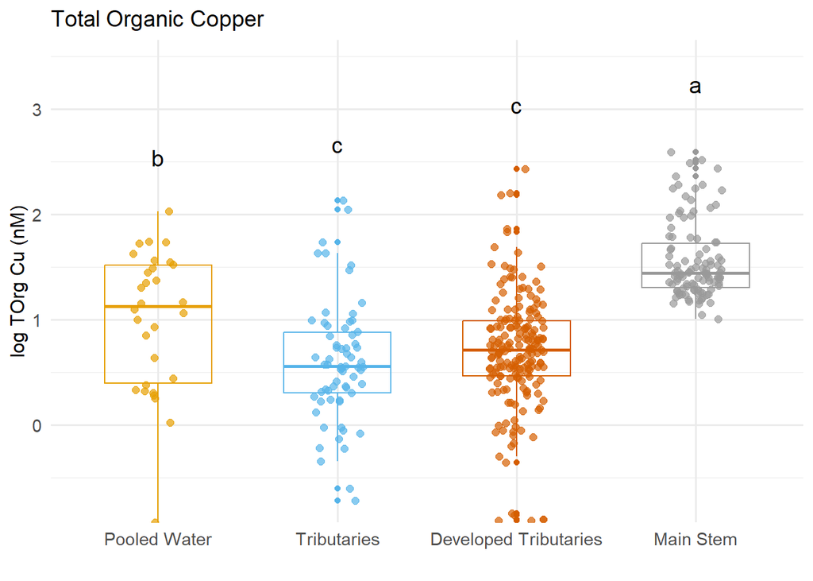

```r
library(dplyr)
library(ggplot2)

#-------------------------------------------------
# 0. Name of the variable you want to plot
#-------------------------------------------------
var_name <- "log_TOrg_Cu_nM"   # or "log_Torg_Cu_nM" if that's the exact name

#-------------------------------------------------
# 1. Titles and y-axis label for this variable
#-------------------------------------------------
title_var   <- "Total Organic Copper"
y_label_var <- "log TOrg Cu (nM)"

# -----------------------------------------------
# 3. Save to an output folder
# -----------------------------------------------
output_dir <- "Plots by Typology"
if (!dir.exists(output_dir)) dir.create(output_dir)

cu_dir <- file.path(output_dir, "Cu Speciation")
if (!dir.exists(cu_dir)) dir.create(cu_dir)

#-------------------------------------------------
# 4. Letters for this variable only (from letters_df)
#-------------------------------------------------
# letters_df has: Variable, Typology, Letters
letters_sub <- letters_df %>%
  filter(Variable == var_name)

#-------------------------------------------------
# 5. y-position for letters: 1.25 * max per Typology
#-------------------------------------------------
y_pos_df <- dat %>%
  group_by(Typology) %>%
  summarise(
    y_pos = max(.data[[var_name]], na.rm = TRUE) * 1.25,
    .groups = "drop"
  )

# join y_pos into letters_sub
letters_sub <- letters_sub %>%
  left_join(y_pos_df, by = "Typology")

#-------------------------------------------------
# 6. Build ggplot for log_TOrg_Cu_nM
#-------------------------------------------------
p_torg_cu <- ggplot(dat, aes(
    x     = Typology,
    y     = .data[[var_name]],
    color = Typology
  )) +
  geom_boxplot(fill = NA, width = 0.6) +
  geom_jitter(
    width = 0.15,
    size  = 2,
    alpha = 0.7
  ) +
  geom_text(
    data = letters_sub,
    aes(
      x = Typology,
      y = y_pos,
      label = Letters
    ),
    inherit.aes = FALSE,
    size = 5
  ) +
  scale_color_manual(values = typology_colors) +
  labs(
    title = title_var,
    y     = y_label_var,
    x     = ""
  ) +
  scale_y_continuous(expand = expansion(mult = c(0, 0.1))) +
  theme_minimal(base_size = 12) +
  theme(
    legend.position = "none",
    axis.text.x  = element_text(size = 11),
    axis.title.x = element_text(size = 12),
    axis.text.y  = element_text(size = 11),
    axis.title.y = element_text(size = 12),
    plot.title   = element_text(size = 14)
  )

# Show the plot
p_torg_cu
```

```r
  ggsave(
    filename = file.path(cu_dir, "Torg_Cu_panel.png"),
    plot     = p_torg_cu,
    width    = 5,
    height   = 4,
    dpi      = 300
  )
```

#### iii. Competing cations

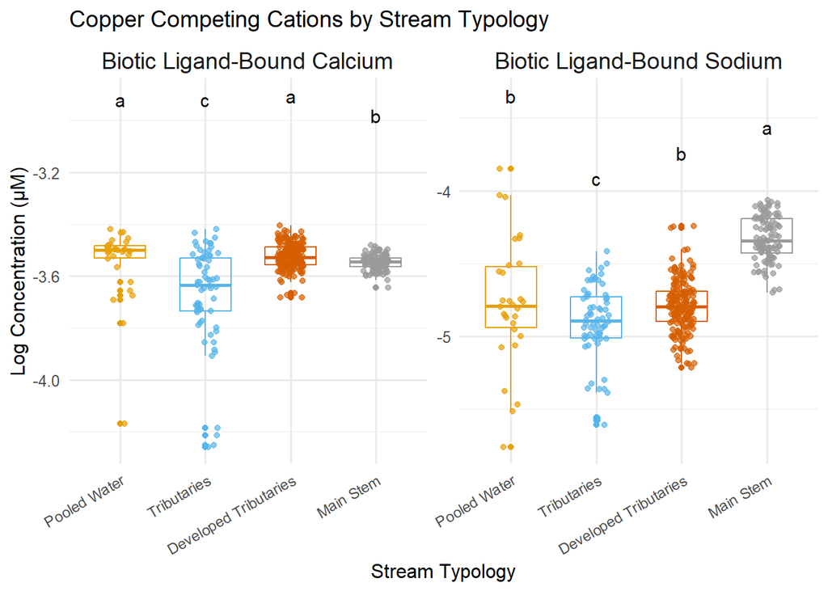

```r
library(dplyr)
library(tidyr)
library(ggplot2)

# ------------------------------------------------
# 0. Variable titles and y-axis labels
# ------------------------------------------------
title_lookup <- c(
  "log_BL_Na_nmol_g_Cu"  = "Biotic Ligand-Bound Sodium",
  "log_BL_Ca_nmol_g_Cu"  = "Biotic Ligand-Bound Calcium"
)

# Custom y-axis labels (optional)
y_label_lookup <- c(
  "log_BL_Na_nmol_g_Cu"  = "log BL-Na (nM)",
  "log_BL_Ca_nmol_g_Cu"  = "log BL-Ca (nM)"
)

vars_zn_spec <- names(title_lookup)

# ------------------------------------------------
# 1. Make sure output folders exist
# ------------------------------------------------
output_dir <- "Plots by Typology"
if (!dir.exists(output_dir)) dir.create(output_dir)

zn_dir <- file.path(output_dir, "Zn Speciation")
if (!dir.exists(zn_dir)) dir.create(zn_dir)

# ------------------------------------------------
# 2. Long-format data for these variables
# ------------------------------------------------
dat_long <- dat %>%
  dplyr::select(Typology, all_of(vars_zn_spec)) %>%
  pivot_longer(
    cols      = -Typology,
    names_to  = "Variable",
    values_to = "Value"
  ) %>%
  filter(!is.na(Value))

# ------------------------------------------------
# 3. Letters for these variables only (from letters_df)
# ------------------------------------------------

# 3a. Max y per Variable x Typology
y_pos_df <- dat_long %>%
  group_by(Variable, Typology) %>%
  summarise(y_max = max(Value, na.rm = TRUE), .groups = "drop")

# 3b. Join letters with y positions
#     letters_df has: Variable, Typology, Letters
letters_long <- letters_df %>%
  filter(Variable %in% vars_zn_spec) %>%
  left_join(
    y_pos_df,
    by = c("Variable", "Typology")
  ) %>%
  mutate(
    y_pos = y_max + 0.5   # Letters above boxplots
  )

# ------------------------------------------------
# 4. Facet labels using title_lookup
# ------------------------------------------------
facet_labels <- as_labeller(title_lookup)

# ------------------------------------------------
# 5. Build faceted Cu competing cations panel
# ------------------------------------------------
cu_cc_panel <- ggplot(dat_long, aes(
    x     = Typology,
    y     = Value,
    color = Typology
  )) +
  geom_boxplot(fill = NA, width = 0.6) +
  geom_jitter(
    width = 0.15,
    size  = 1.5,
    alpha = 0.7
  ) +
  geom_text(
    data = letters_long,
    aes(x = Typology, y = y_pos, label = Letters),
    inherit.aes = FALSE,
    size = 4
  ) +
  scale_color_manual(values = typology_colors) +
  facet_wrap(
    ~ Variable,
    scales   = "free_y",
    ncol     = 3,
    labeller = facet_labels
  ) +
  labs(
    title = "Copper Competing Cations by Stream Typology",
    x     = "Stream Typology",
    y     = "Log Concentration (µM)"
  ) +
  theme_minimal(base_size = 12) +
  theme(
    legend.position = "none",
    axis.text.x  = element_text(size = 9, angle = 30, hjust = 1),
    strip.text   = element_text(size = 14),
    plot.title   = element_text(size = 14)
  )

# 6. Show in RStudio
cu_cc_panel
```

Save plot

```r
ggsave(
  filename = file.path(cu_dir, "Cu_competing_cations.png"),
  plot     = cu_cc_panel,
  width    = 8,
  height   = 4,
  dpi      = 300
)
```

### e. Toxicity

#### i. Zinc toxicity

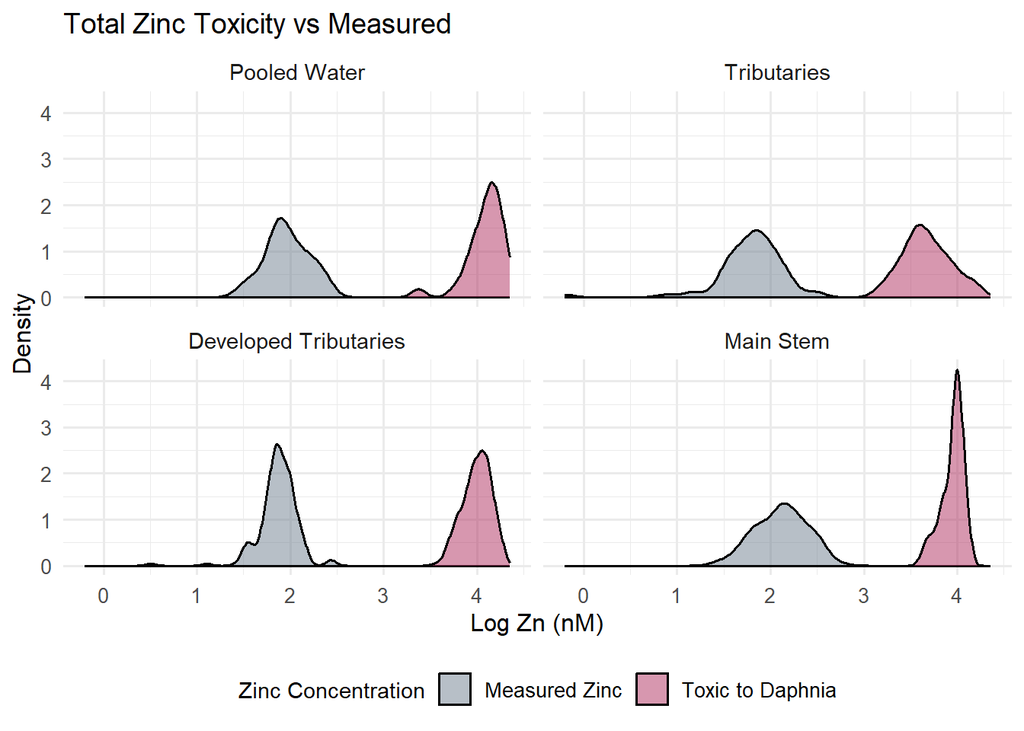

```r
library(dplyr)
library(ggplot2)

p_zn_daph_density <- ggplot(dat, aes(x = log_Zn_nM)) +

  # Measured Zinc density
  geom_density(
    aes(fill = "Measured Zinc"),
    alpha = 0.5,
    linewidth = 0.6,
    na.rm = TRUE
  ) +

  # Zn toxicity density
  geom_density(
    aes(x = log_Zn_Toxicity_Daphnia_nM, fill = "Toxic to Daphnia"),
    alpha = 0.5,
    linewidth = 0.6,
    na.rm = TRUE
  ) +

  # Facet by Typology
  facet_wrap(~ Typology, ncol = 2) +

  # Manual fill colors + legend title
  scale_fill_manual(
    name   = "Zinc Concentration",
    values = c(
      "Measured Zinc"    = "slategray",
      "Toxic to Daphnia" = "maroon"
    )
  ) +

  # Labels
  labs(
    title = "Total Zinc Toxicity vs Measured",
    x     = "Log Zn (nM)",
    y     = "Density"
  ) +

  # Clean theme
  theme_minimal(base_size = 12) +
  theme(
    legend.position = "bottom",
    legend.title    = element_text(size = 11),
    legend.text     = element_text(size = 10),
    strip.text      = element_text(size = 11),
    axis.text.x     = element_text(size = 10),
    axis.text.y     = element_text(size = 10),
    plot.title      = element_text(size = 14)
  )

# Print plot
p_zn_daph_density
```

Save to folder called Plot of Zn Toxicity

```r
# Define output directory
out_dir <- "Plot of Zn Toxicity"

# Create folder if it doesn't exist
if (!dir.exists(out_dir)) {
  dir.create(out_dir, recursive = TRUE)
}

# Save plot
ggsave(
  filename = file.path(out_dir, "Zn_toxicity_daphnia.png"),
  plot = p_zn_daph_density,
  width = 8,
  height = 6,
  units = "in",
  dpi = "print"
)
```

Calculate the probability of Zn toxicity to daphnia by typology

```r
#Quantify overlapping area of measured zinc with toxic concentrations by typology

# Extract the two vectors
x1 <- dat$log_Zn_nM
x2 <- dat$log_Zn_Toxicity_Daphnia_nM

library(dplyr)

# --- Define overlap function ---
overlap_area <- function(x, y, n = 512) {
  d1 <- density(x, na.rm = TRUE, n = n)
  d2 <- density(y, na.rm = TRUE, n = n)

  x_start <- max(min(d1$x), min(d2$x))
  x_end   <- min(max(d1$x), max(d2$x))

  if(x_start >= x_end) return(0)  # No overlap

  x_common <- seq(x_start, x_end, length.out = n)
  y1 <- approx(d1$x, d1$y, x_common)$y
  y2 <- approx(d2$x, d2$y, x_common)$y

  sum(pmin(y1, y2)) * diff(x_common[1:2])
}


# --- Compute overlaps by Typology ---
overlap_Zn_by_typology <- dat %>%
  group_by(Typology) %>%
  summarise(
    Overlap_Daphnia = overlap_area(log_Zn_nM, log_Zn_Toxicity_Daphnia_nM)
  ) %>%
  ungroup()

# View results
overlap_Zn_by_typology
```

| Typology | Overlap_Daphnia |
| --- | --- |
| Pooled Water | 0 |
| Tributaries | 0 |
| Developed Tributaries | 0 |
| Main Stem | 0 |

Save to folder

```r
library(openxlsx)

# 1. Define output folder (relative to working directory)
out_dir <- "Plot of Zn Toxicity"

# 2. Create folder if it doesn't exist
if (!dir.exists(out_dir)) {
  dir.create(out_dir, recursive = TRUE)
}

# 3. Define file path
file_path <- file.path(out_dir, "overlap_Zn_by_typology.xlsx")

# 4. Create workbook and write table
wb <- createWorkbook()
addWorksheet(wb, "Overlap_Zn_by_Typology")
writeData(wb, "Overlap_Zn_by_Typology", overlap_Zn_by_typology)

# 5. Save
saveWorkbook(wb, file_path, overwrite = TRUE)
```

#### ii. Copper toxicity

Toxicity to Daphnia

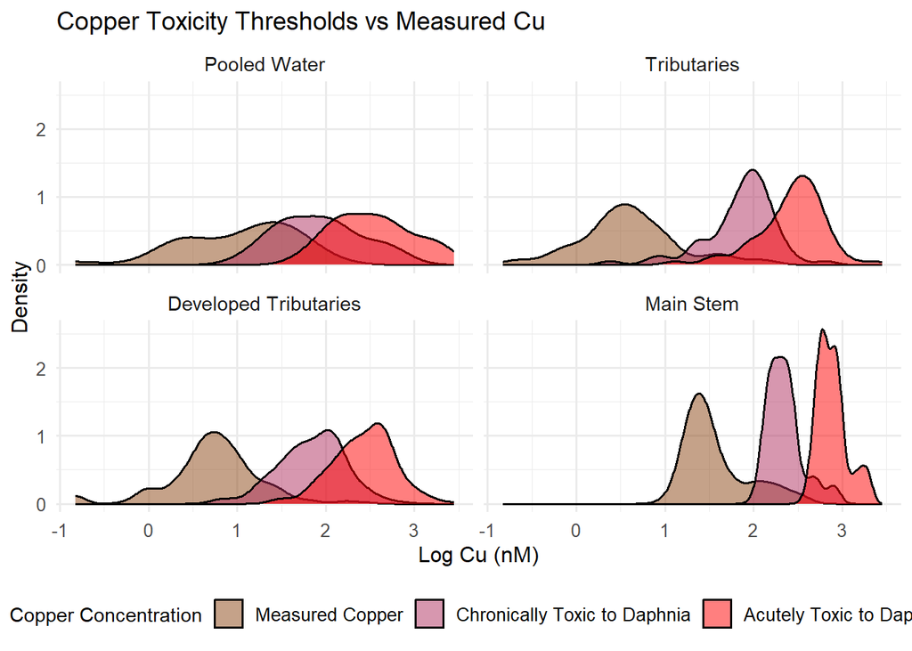

```r
library(dplyr)

# 1. Pivot to long format
dat_cu_daph <- dat %>%
  dplyr::select(
    Typology,
    log_Cu_nM,
    log_Cu_Chronic_Toxicity_Daphnia_nM,
    log_Cu_Acute_Toxicity_Daphnia_nM
  ) %>%
  pivot_longer(
    cols      = c(
      log_Cu_nM,
      log_Cu_Chronic_Toxicity_Daphnia_nM,
      log_Cu_Acute_Toxicity_Daphnia_nM
    ),
    names_to  = "Copper_Concentrations",
    values_to = "Value"
  ) %>%
  mutate(
    Copper_Concentrations = dplyr::recode(
      Copper_Concentrations,
      "log_Cu_nM"                          = "Measured Copper",
      "log_Cu_Chronic_Toxicity_Daphnia_nM" = "Chronically Toxic to Daphnia",
      "log_Cu_Acute_Toxicity_Daphnia_nM"   = "Acutely Toxic to Daphnia"
    ),
    Copper_Concentrations = factor(
      Copper_Concentrations,
      levels = c(
        "Measured Copper",
        "Chronically Toxic to Daphnia",
        "Acutely Toxic to Daphnia"
      )
    )
  ) %>%
  filter(!is.na(Value))

# 2. Density plot faceted by Typology
p_cu_daph_density <- ggplot(
    dat_cu_daph,
    aes(x = Value, fill = Copper_Concentrations)
  ) +
  geom_density(alpha = 0.5, linewidth = 0.6) +
  facet_wrap(~ Typology, ncol = 2) +
  scale_fill_manual(values = c(
    "Measured Copper"              = "chocolate4",
    "Chronically Toxic to Daphnia" = "maroon",
    "Acutely Toxic to Daphnia"     = "red"
  )) +
  labs(
    title = "Copper Toxicity Thresholds vs Measured Cu",
    x     = "Log Cu (nM)",
    y     = "Density",
    fill  = "Copper Concentration"
  ) +
  theme_minimal(base_size = 12) +
  theme(
    legend.position = "bottom",
    legend.title    = element_text(size = 11),
    legend.text     = element_text(size = 10),
    strip.text      = element_text(size = 11),
    axis.text.x     = element_text(size = 10),
    axis.text.y     = element_text(size = 10),
    plot.title      = element_text(size = 14)
  )

p_cu_daph_density
```

Save to folder called Plots of Cu Toxicity

```r
# Define output directory
out_dir <- "Plots of Cu Toxicity"

# Create folder if it doesn't exist
if (!dir.exists(out_dir)) {
  dir.create(out_dir, recursive = TRUE)
}

# Save plot
ggsave(
  filename = file.path(out_dir, "Cu_toxicity_daphnia.png"),
  plot = p_cu_daph_density,
  width = 8,
  height = 6,
  units = "in",
  dpi = "print"
)
```

Toxicity to Minnow

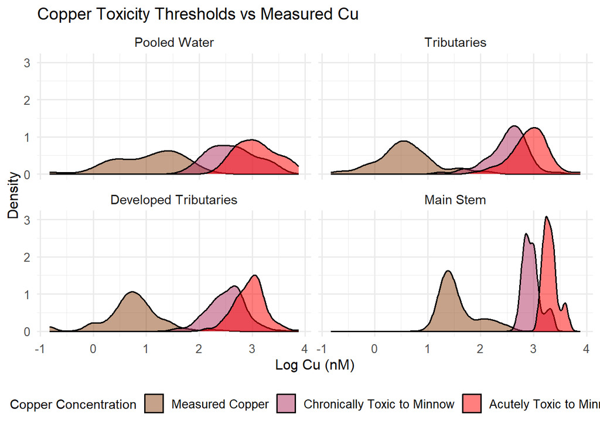

```r
library(dplyr)
library(ggplot2)

# 1. Pivot to long format
dat_cu_minn <- dat %>%
  dplyr::select(
    Typology,
    log_Cu_nM,
    log_Cu_Chronic_Toxicity_Minnow_nM,
    log_Cu_Acute_Toxicity_Minnow_nM
  ) %>%
  pivot_longer(
    cols      = c(
      log_Cu_nM,
      log_Cu_Chronic_Toxicity_Minnow_nM,
      log_Cu_Acute_Toxicity_Minnow_nM
    ),
    names_to  = "Copper_Concentrations",
    values_to = "Value"
  ) %>%
  mutate(
    Copper_Concentrations = dplyr::recode(
      Copper_Concentrations,
      "log_Cu_nM"                          = "Measured Copper",
      "log_Cu_Chronic_Toxicity_Minnow_nM" = "Chronically Toxic to Minnow",
      "log_Cu_Acute_Toxicity_Minnow_nM"   = "Acutely Toxic to Minnow"
    ),
    Copper_Concentrations = factor(
      Copper_Concentrations,
      levels = c(
        "Measured Copper",
        "Chronically Toxic to Minnow",
        "Acutely Toxic to Minnow"
      )
    )
  ) %>%
  filter(!is.na(Value))

# 2. Density plot faceted by Typology
p_cu_daph_density_minn <- ggplot(
    dat_cu_minn,
    aes(x = Value, fill = Copper_Concentrations)
  ) +
  geom_density(alpha = 0.5, linewidth = 0.6) +
  facet_wrap(~ Typology, ncol = 2) +
  scale_fill_manual(values = c(
    "Measured Copper"              = "chocolate4",
    "Chronically Toxic to Minnow" = "maroon",
    "Acutely Toxic to Minnow"     = "red"
  )) +
  labs(
    title = "Copper Toxicity Thresholds vs Measured Cu",
    x     = "Log Cu (nM)",
    y     = "Density",
    fill  = "Copper Concentration"
  ) +
  theme_minimal(base_size = 12) +
  theme(
    legend.position = "bottom",
    legend.title    = element_text(size = 11),
    legend.text     = element_text(size = 10),
    strip.text      = element_text(size = 11),
    axis.text.x     = element_text(size = 10),
    axis.text.y     = element_text(size = 10),
    plot.title      = element_text(size = 14)
  )

p_cu_daph_density_minn
```

Save to folder called Plots of Cu Toxicity

```r
# Define output directory
out_dir <- "Plots of Cu Toxicity"

# Create folder if it doesn't exist
if (!dir.exists(out_dir)) {
  dir.create(out_dir, recursive = TRUE)
}

# Save plot
ggsave(
  filename = file.path(out_dir, "Cu_toxicity_minnow.png"),
  plot = p_cu_daph_density_minn,
  width = 8,
  height = 6,
  units = "in",
  dpi = "print"
)
```

Calculate probability of overlapping measured copper with toxic levels of copper by stream typology

```r
#Quantify overlapping area of measured copper with toxic concentrations by typology

# Extract the two vectors
x1 <- dat$log_Cu_nM
x2 <- dat$log_Cu_Chronic_Toxicity_Daphnia_nM
x3 <- dat$log_Cu_Acute_Toxicity_Daphnia_nM
x4 <- dat$log_Cu_Chronic_Toxicity_Minnow_nM
x5 <- dat$log_Cu_Acute_Toxicity_Minnow_nM

# Compute density overlaps between measured Cu and toxicity thresholds
library(dplyr)

overlap_area <- function(x, y, n = 512) {
  d1 <- density(x, n = n)
  d2 <- density(y, n = n)

  # Common x grid
  x_common <- seq(max(min(d1$x), min(d2$x)), min(max(d1$x), max(d2$x)), length.out = n)

  y1 <- approx(d1$x, d1$y, x_common)$y
  y2 <- approx(d2$x, d2$y, x_common)$y

  # Area under the minimum of both density curves
  overlap <- sum(pmin(y1, y2)) * diff(x_common[1:2])
  return(overlap)
}

# --- Compute overlaps by Typology ---
overlap_results_by_typology <- dat %>%
  group_by(Typology) %>%
  summarise(

    Overlap_Chronic_Toxicity_Daphnia =
      overlap_area(log_Cu_nM, log_Cu_Chronic_Toxicity_Daphnia_nM),

    Overlap_Acute_Toxicity_Daphnia   =
      overlap_area(log_Cu_nM, log_Cu_Acute_Toxicity_Daphnia_nM),

    Overlap_Chronic_Toxicity_Minnow  =
      overlap_area(log_Cu_nM, log_Cu_Chronic_Toxicity_Minnow_nM),

    Overlap_Acute_Toxicity_Minnow    =
      overlap_area(log_Cu_nM, log_Cu_Acute_Toxicity_Minnow_nM)

    ) %>%
  ungroup()

# View
overlap_results_by_typology
```

| Typology | Overlap_Chronic_Toxicity_Daphnia | Overlap_Acute_Toxicity_Daphnia | Overlap_Chronic_Toxicity_Minnow | Overlap_Acute_Toxicity_Minnow |
| --- | --- | --- | --- | --- |
| Pooled Water | 0.4979319 | 0.16627947 | 0.13098139 | 0.02174791 |
| Tributaries | 0.1954247 | 0.10797894 | 0.09447321 | 0.03821047 |
| Developed Tributaries | 0.2045887 | 0.06150330 | 0.05171828 | 0.01803042 |
| Main Stem | 0.1702998 | 0.02017694 | 0.01097498 | NA |

Save table to folder

```r
library(openxlsx)

# 1. Define output folder (relative to working directory)
out_dir <- "Plots of Cu Toxicity"

# 2. Create folder if it doesn't exist
if (!dir.exists(out_dir)) {
  dir.create(out_dir, recursive = TRUE)
}

# 3. Define file path
file_path <- file.path(out_dir, "overlap_Cu_by_typology.xlsx")

# 4. Create workbook and write table
wb <- createWorkbook()
addWorksheet(wb, "Overlap_Cu_by_Typology")
writeData(wb, "Overlap_Cu_by_Typology", overlap_results_by_typology)

# 5. Save
saveWorkbook(wb, file_path, overwrite = TRUE)
```

# Variables by Site within Typology

## **1. Main Stem**

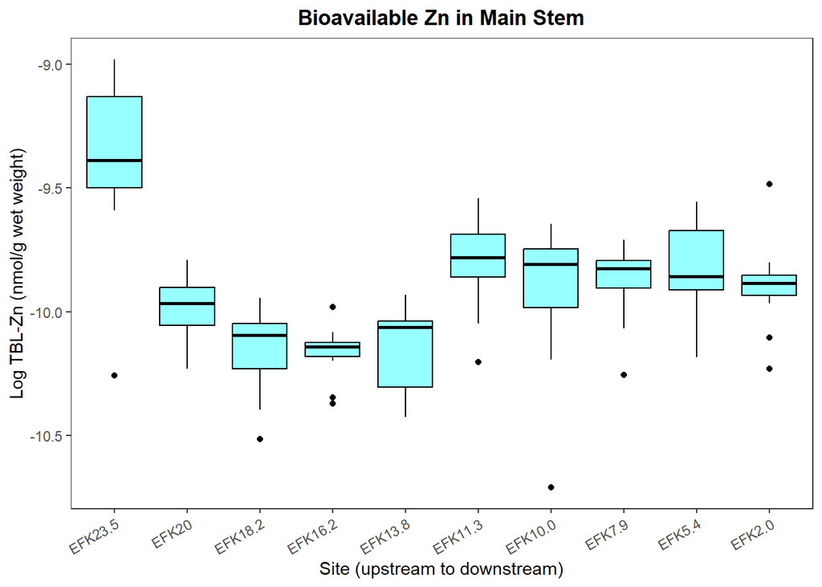

```r
library(dplyr)
library(stringr)

# Isolate Main Stem typology and order the sites
ms_typology <- dat %>%
  filter(Typology == "Main Stem") %>%
  mutate(
    Site = factor(Site, levels = c(
      "EFK23.5","EFK20","EFK18.2","EFK16.2","EFK13.8",
      "EFK11.3","EFK10.0","EFK7.9","EFK5.4","EFK2.0"
    ))
  )

# Plot by site
library(ggplot2)

# Zinc
main_stem_plot_zn <- ggplot(
  ms_typology,
  aes(x = Site, y = log_TBL_Zn_nmol_g)
) +
  geom_boxplot(
    fill = "darkslategray1",
    color = "black",
    position = position_dodge(width = 0.75)
  ) +
  labs(
    title = "Bioavailable Zn in Main Stem",
    x = "Site (upstream to downstream)",
    y = "Log TBL-Zn (nmol/g wet weight)"
  ) +
  theme_test() +
  theme(
    axis.text.x = element_text(angle = 30, hjust = 1),
    plot.title = element_text(hjust = 0.5, face = "bold"),
    legend.position = "none"
  )

# Copper
main_stem_plot_cu <- ggplot(
  ms_typology,
  aes(x = Site, y = log_TBL_Cu_nmol_g)
) +
  geom_boxplot(
    fill = "chocolate1",
    color = "black",
    position = position_dodge(width = 0.75)
  ) +
  labs(
    title = "Bioavailable Cu in Main Stem",
    x = "Site (upstream to downstream)",
    y = "Log TBL-Cu (nmol/g wet weight)"
  ) +
  theme_test() +
  theme(
    axis.text.x = element_text(angle = 30, hjust = 1),
    plot.title = element_text(hjust = 0.5, face = "bold"),
    legend.position = "none"
  )

# View
main_stem_plot_zn
```

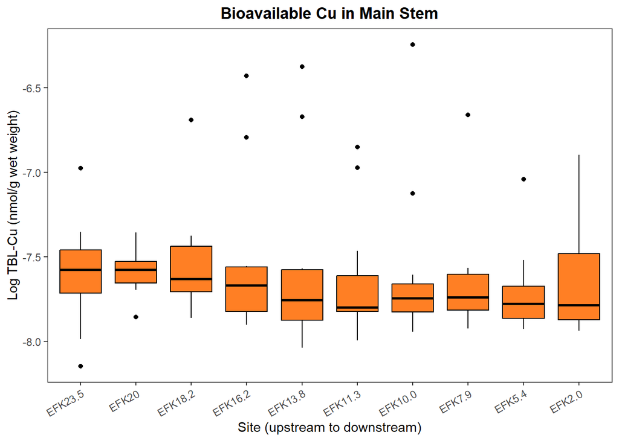

```r
main_stem_plot_cu
```

Save to folder called Plots of Main Stem

```r
# Define output directory
out_dir <- "Plots of Main Stem"

# Create folder if it doesn't exist
if (!dir.exists(out_dir)) {
  dir.create(out_dir, recursive = TRUE)
}

# Save plots
ggsave(
  filename = file.path(out_dir, "Bioavailable_Zn_by_site.png"),
  plot = main_stem_plot_zn,
  width = 8,
  height = 5,
  units = "in",
  dpi = "print"
)

ggsave(
  filename = file.path(out_dir, "Bioavailable_Cu_by_site.png"),
  plot = main_stem_plot_cu,
  width = 8,
  height = 5,
  units = "in",
  dpi = "print"
)
```

## 2. Developed Tributaries

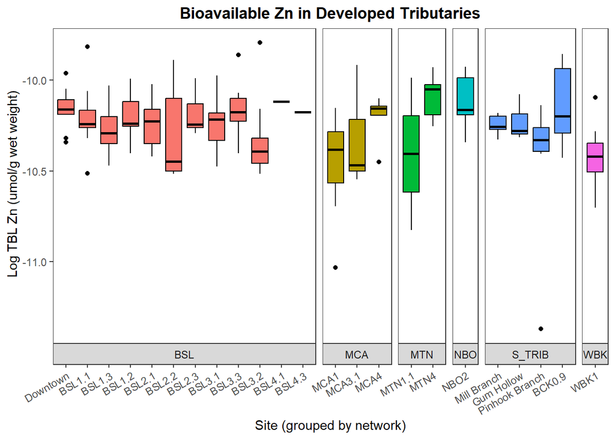

```r
library(dplyr)

# Isolate typology and order the sites
dt_typology <- dat %>%
  filter(Typology == "Developed Tributaries") %>%
  mutate(Site = factor(Site,
                       levels = unique(Site[order(Dist_from_EFPC_km)])))


# Plot by site colored by Network
library(ggplot2)

# Zinc
dev_tribs_plot_zn <- ggplot(dt_typology, aes(x = Site, y = log_TBL_Zn_nmol_g, fill = Network)) +
  geom_boxplot(color = "black", position = position_dodge(width = 0.75)) +
  labs(
    title = "Bioavailable Zn in Developed Tributaries",
    x = "Site (grouped by network)",
    y = " Log TBL Zn (umol/g wet weight)"
  ) +
  theme_test() +
  theme(
    axis.text.x = element_text(angle = 30, hjust = 1),
    legend.position = "none",
    plot.title = element_text(hjust = 0.5, face = "bold")
  ) +

  # Add vertical dividers between networks
  facet_grid(~Network, scales = "free_x", space = "free_x", switch = "x")

# Copper
dev_tribs_plot_cu <- ggplot(dt_typology, aes(x = Site, y = log_TBL_Cu_nmol_g, fill = Network)) +
  geom_boxplot(color = "black", position = position_dodge(width = 0.75)) +
  labs(
    title = "Bioavailable Cu in Developed Tributaries",
    x = "Site (grouped by network)",
    y = " Log TBL Cu (umol/g wet weight)"
  ) +
  theme_test() +
  theme(
    axis.text.x = element_text(angle = 30, hjust = 1),
    legend.position = "none",
    plot.title = element_text(hjust = 0.5, face = "bold")
  ) +

  # Add vertical dividers between networks
  facet_grid(~Network, scales = "free_x", space = "free_x", switch = "x")

# View
dev_tribs_plot_zn
```

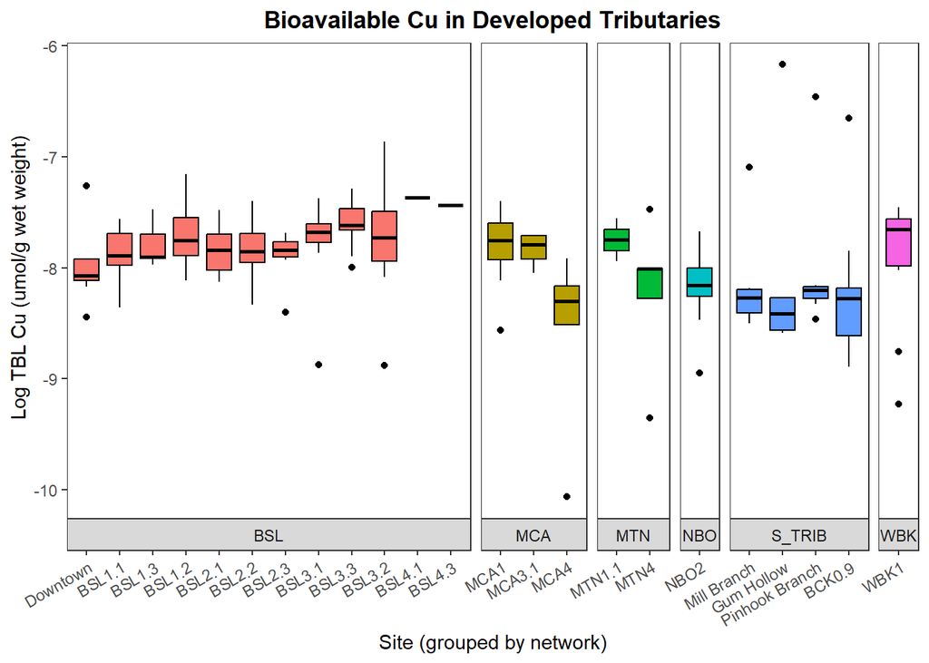

```r
dev_tribs_plot_cu
```

Save to folder called Plots of Developed Tributaries

```r
# Define output directory
out_dir <- "Plots of Developed Tributaries"

# Create folder if it doesn't exist
if (!dir.exists(out_dir)) {
  dir.create(out_dir, recursive = TRUE)
}

# Save plots
ggsave(
  filename = file.path(out_dir, "Bioavailable_Zn_by_site.png"),
  plot = dev_tribs_plot_zn,
  width = 8,
  height = 5,
  units = "in",
  dpi = "print"
)

ggsave(
  filename = file.path(out_dir, "Bioavailable_Cu_by_site.png"),
  plot = dev_tribs_plot_cu,
  width = 8,
  height = 5,
  units = "in",
  dpi = "print"
)
```

## **3. Tributaries**

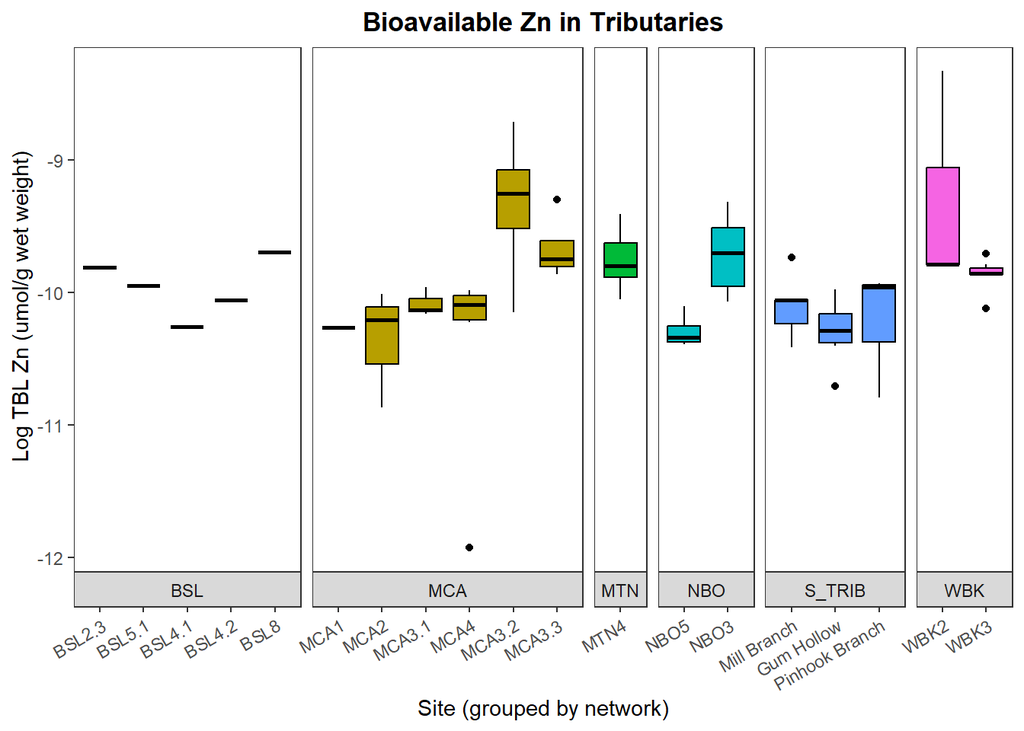

```r
library(dplyr)

# Isolate typology and order the sites
t_typology <- dat %>%
  filter(Typology == "Tributaries") %>%
  mutate(Site = factor(Site,
                       levels = unique(Site[order(Dist_from_EFPC_km)])))


# Plot by site colored by Network
library(ggplot2)

# Zinc
f_tribs_plot_zn <- ggplot(t_typology, aes(x = Site, y = log_TBL_Zn_nmol_g, fill = Network)) +
  geom_boxplot(color = "black", position = position_dodge(width = 0.75)) +
  labs(
    title = "Bioavailable Zn in Tributaries",
    x = "Site (grouped by network)",
    y = " Log TBL Zn (umol/g wet weight)"
  ) +
  theme_test() +
  theme(
    axis.text.x = element_text(angle = 30, hjust = 1),
    legend.position = "none",
    plot.title = element_text(hjust = 0.5, face = "bold")
  ) +

  # Add vertical dividers between networks
  facet_grid(~Network, scales = "free_x", space = "free_x", switch = "x")

# Copper
f_tribs_plot_cu <- ggplot(t_typology, aes(x = Site, y = log_TBL_Cu_nmol_g, fill = Network)) +
  geom_boxplot(color = "black", position = position_dodge(width = 0.75)) +
  labs(
    title = "Bioavailable Cu in Flowing Tributaries",
    x = "Site (grouped by network)",
    y = " Log TBL Cu (umol/g wet weight)"
  ) +
  theme_test() +
  theme(
    axis.text.x = element_text(angle = 30, hjust = 1),
    legend.position = "none",
    plot.title = element_text(hjust = 0.5, face = "bold")
  ) +

  # Add vertical dividers between networks
  facet_grid(~Network, scales = "free_x", space = "free_x", switch = "x")

# View
f_tribs_plot_zn
```

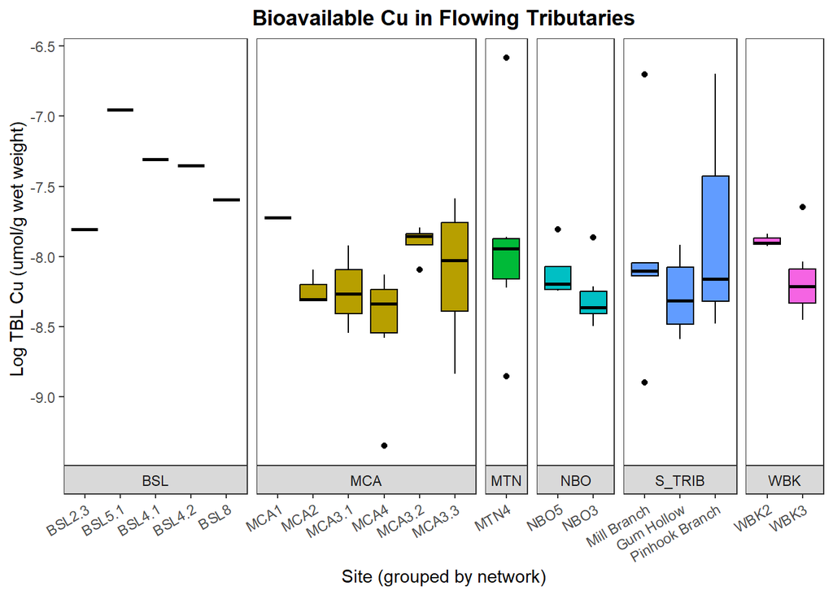

```r
f_tribs_plot_cu
```

Save to folder called Plots of Flowing Tributaries

```r
# Define output directory
out_dir <- "Plots of Flowing Tributaries"

# Create folder if it doesn't exist
if (!dir.exists(out_dir)) {
  dir.create(out_dir, recursive = TRUE)
}

# Save plots
ggsave(
  filename = file.path(out_dir, "Bioavailable_Zn_by_site.png"),
  plot = f_tribs_plot_zn,
  width = 8,
  height = 5,
  units = "in",
  dpi = "print"
)

ggsave(
  filename = file.path(out_dir, "Bioavailable_Cu_by_site.png"),
  plot = f_tribs_plot_cu,
  width = 8,
  height = 5,
  units = "in",
  dpi = "print"
)
```

## 4. Pooled Water

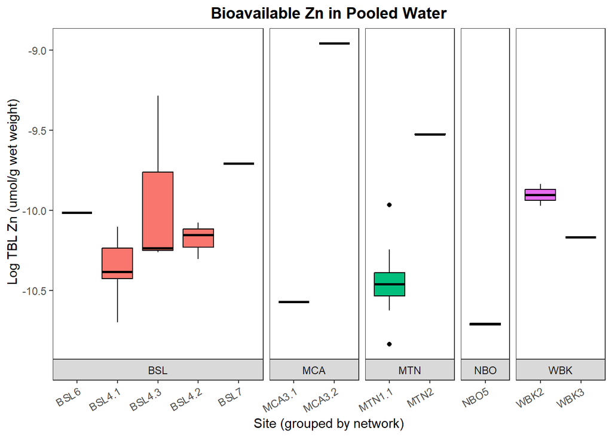

```r
library(dplyr)

# Isolate typology and order the sites
pw_typology <- dat %>%
  filter(Typology == "Pooled Water") %>%
  mutate(Site = factor(Site,
                       levels = unique(Site[order(Dist_from_EFPC_km)])))


# Plot by site colored by Network
library(ggplot2)

# Zinc
pooled_water_plot_zn <- ggplot(
  pw_typology, aes(x = Site, y = log_TBL_Zn_nmol_g, fill = Network)) +
  geom_boxplot(color = "black", position = position_dodge(width = 0.75)) +
  labs(
    title = "Bioavailable Zn in Pooled Water",
    x = "Site (grouped by network)",
    y = " Log TBL Zn (umol/g wet weight)"
  ) +
  theme_test() +
  theme(
    axis.text.x = element_text(angle = 30, hjust = 1),
    legend.position = "none",
    plot.title = element_text(hjust = 0.5, face = "bold")
  ) +

  # Add vertical dividers between networks
  facet_grid(~Network, scales = "free_x", space = "free_x", switch = "x")

# Copper
pooled_water_plot_cu <- ggplot(pw_typology, aes(x = Site, y = log_TBL_Cu_nmol_g, fill = Network)) +
  geom_boxplot(color = "black", position = position_dodge(width = 0.75)) +
  labs(
    title = "Bioavailable Cu in Pooled Water",
    x = "Site (grouped by network)",
    y = " Log TBL Cu (umol/g wet weight)"
  ) +
  theme_test() +
  theme(
    axis.text.x = element_text(angle = 30, hjust = 1),
    legend.position = "none",
    plot.title = element_text(hjust = 0.5, face = "bold")
  ) +

  # Add vertical dividers between networks
  facet_grid(~Network, scales = "free_x", space = "free_x", switch = "x")

# View
pooled_water_plot_zn
```

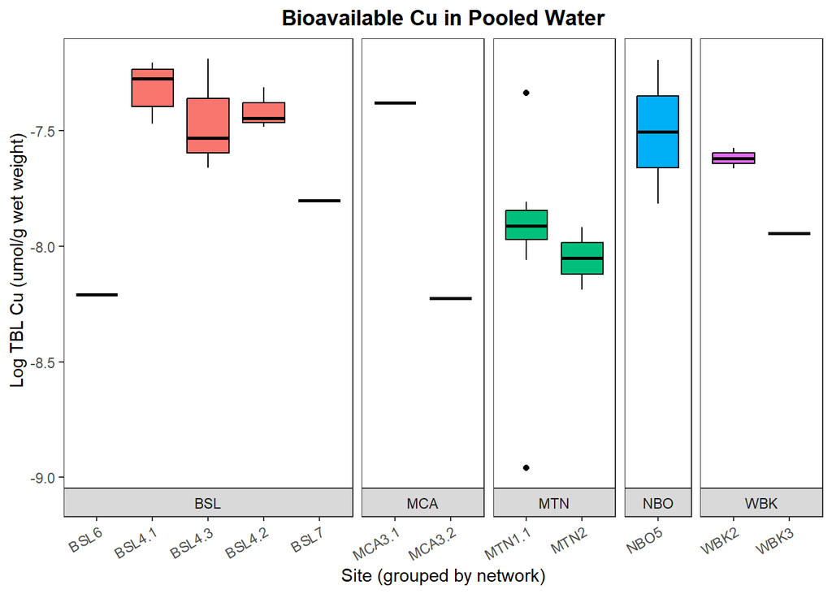

```r
pooled_water_plot_cu
```

Save to folder called Plots of Pooled Water

```r
# Define output directory
out_dir <- "Plots of Pooled Water"

# Create folder if it doesn't exist
if (!dir.exists(out_dir)) {
  dir.create(out_dir, recursive = TRUE)
}

# Save plots
ggsave(
  filename = file.path(out_dir, "Bioavailable_Zn_by_site.png"),
  plot = pooled_water_plot_zn,
  width = 8,
  height = 5,
  units = "in",
  dpi = "print"
)

ggsave(
  filename = file.path(out_dir, "Bioavailable_Cu_by_site.png"),
  plot = pooled_water_plot_cu,
  width = 8,
  height = 5,
  units = "in",
  dpi = "print"
)
```